# SI model of an HIV vaccine trial

Josh Herbeck

2021-04-04

```r
library(deSolve)
library(tidyverse)
library(EpiModel)
library(survival)
library(EasyABC)
```

### Using models to assess the impact of vaccine leakiness on trial vaccine efficacy measures.

It is hypothesized that exposure heterogeneity (i.e. infection risk heterogeneity) can affect efficacy estimation for leaky vaccines (e.g. Halloran et al., 1992; White et al., 2010; O’Hagan et al.,2013; Edlefsen, 2014; Coley et al., 2016; Gomes et al., 2016; Kahn et al., 2018). Our goal is to make a simple deterministic compartmental model to facilitate straightforward simulation-based evaluation of this process within and across populations, in the context of HIV prevention trials or longitudinal studies.

1. In acute infection studies it seems like many participants get infected early. What is the magnitude of this effect that might be due to frailty bias?
2. Assess if this effect might contribute to the differences between the RV 144 and HVTN 702 vaccine trial outcomes. (There have been a couple of analyses of this, and we can build on this and make future analyses of other trial results more straightforward to evaluate.)
3. Assess if this effect might contribute to the waning efficacies seen in HIV prevention trials (specifically the AMP VRC01 bnAb trial).
4. In the context of the AMP Trial and the different results seen in the sub-studies (703 vs 704); is this due to different forces of infection between the populations?
5. Continue to raise awareness of this issue to HIV prevention trials, with the ultimate goal of better design and interpretation of efficacy outcomes.

From Gomes et al., 2016: “This effect is more pronounced in the control group as individuals within it experience higher rates of infection overall. Consequently, the ratio of disease rates in vaccinated over control groups increases, and vaccine efficacy, as measured by simple rate ratios, decreases as the trial progresses. Finally, the magnitude of this effect increases with the intensity of transmission.”

### Model setup

We are modeling a closed population SI deterministic compartmental model meant to simulate a vaccine trial. We are not modeling infections from I to S but rather only infections from the outside (non-trial) population, with the infection rate based on the population prevalence `prev` (of viremic individuals), the exposure rate (serodiscordant sexual contacts per time) `c`, and the transmission rate (per contact) `p`. The per contact effect of vaccination is `epsilon`, and with this iteration of the model `epsilon` is: 1) not time-varying (the per contact vaccine effect does not decay over time); and 2) assumes a homogeneous effect (does not vary by mark / viral genotype). This model structure also removes the possibility of indirect effects from vaccination.

`beta` = transmission rate (per contact)  
`c` = exposure rate (serodiscordant sexual contacts per time)  
`prev` = prevalence (prevalence of viremic individuals)  
`lambda = beta * c * prev`  
`risk` = risk multiplier  
`epsilon` = per contact vaccine efficacy; vaccine-induced reduction in the risk of HIV infection from a single exposure

The risk multiplier is an amalgam of increases in transmission risk that could be due to: 1) increased per contact transmission risk; 2) increased exposure rate (number of contacts); or 3) increased prevalence of HIV viremia in partners. Individual risk of infection can vary for these separately or in combination.

Basic functions:

`dS/dt = -lambda*S`  
`dI/dt = lambda*S`

Sp = susceptible placebo  
Ip = infected placebo  
Sv = susceptible vaccinated  
Iv = infected vaccinated

### Calibration, first step

AT this stage we just eyeball-calibrated the incidence to ~3.5% per 100 person years, to be reasonably consistent with HVTN 702 in South Africa. (More quantitative ABC calibration is below.) We used an initial set of transmission parameters for sub-Saharan Africa borrowing from Alain Vandormael (2018):

```
 "We used realistic parameter values for the SIR model, based on earlier HIV studies that have been undertaken in the sub-Saharan Africa context. To this extent, we varied `c` within the range of 50 to 120 sexual acts per year based on data collected from serodiscordant couples across eastern and southern African sites. Previous research has shown considerable heterogeneity in the probability of HIV transmission per sexual contact, largely due to factors associated with the viral load level, genital ulcer disease, stage of HIV progression, condom use, circumcision and use of ART. Following a systematic review of this topic by Boily et al., we selected values for `beta` within the range of 0.003–0.008. ... Here, we chose values for `v` within the range of 0.15–0.35, which are slightly conservative, but supported by population-based estimates from the sub-Saharan African context."
```

`c` varies from 50 to 120 per year  
`beta` varies from 0.003 to 0.008  
`prev`, which here is population prevalence of unsuppressed VL, varies from 0.15 to 0.35  
`epsilon` could be parameterized using the RV144 Thai Trial results: VE = 61% at 12 months, 31% at 42 months, but below we start with 30% and no waning efficacy. A vaccine duration parameter is not needed because we are only modeling a 3 year trial without boosters.

### Model function; ODEs

Right now this includes just two vaccine trial populations, each with a vaccine arm and a placebo arm. One population has homogeneous exposure / risk of infection; the other population includes exposure heterogeneity, and this heterogeneity is the same in both trial arms.

```r
si_ode <- function(times, init, param){
  with(as.list(c(init, param)), {

    # Flows
    # the number of people moving from S to I at each time step
    #Susceptible, Infected, placebo
    SIp.flow <- lambda*Sp
    SIv.flow <- lambda*(1-epsilon)*Sv

    #Susceptible, Infected, placebo, high, medium, low
    SIph.flow <- risk*lambda*Sph
    SIpm.flow <- lambda*Spl
    #SIpl.flow <- 0*lambda*Spl  #zero risk in the low risk group
    SIpl.flow <- (1/risk)*lambda*Spl  #inverse risk multiplier for low risk group

    #Susceptible, Infected, vaccine, high, medium, low
    SIvh.flow <- risk*lambda*(1-epsilon)*Svh
    SIvm.flow <- lambda*(1-epsilon)*Spl
    #SIvl.flow <- 0*lambda*(1-epsilon)*Svl  #zero risk in the low risk group
    SIvl.flow <- (1/risk)*lambda*(1-epsilon)*Svl  #inverse risk

    # ODEs
    # placebo; homogeneous risk
    dSp <- -SIp.flow
    dIp <- SIp.flow  #lambda*Sp

    # vaccine; homogeneous risk
    dSv <- -SIv.flow
    dIv <- SIv.flow  #lambda*epsilon*Sv

    # placebo; heterogeneous risk
    dSph <- -SIph.flow
    dIph <- SIph.flow  #risk*lambda*Sph
    dSpm <- -SIpm.flow
    dIpm <- SIpm.flow  #lambda*Spm
    dSpl <- -SIpl.flow
    dIpl <- SIpl.flow  #0*lambda*Spl

    # vaccine; heterogeneous risk
    dSvh <- -SIvh.flow
    dIvh <- SIvh.flow  #risk*lambda*(1-epsilon)*Svh
    dSvm <- -SIvm.flow
    dIvm <- SIvm.flow  #lambda*Svm
    dSvl <- -SIvl.flow
    dIvl <- SIvl.flow  #0*lambda*(1-epsilon)*Svl

    #Output
    list(c(dSp,dIp,
           dSv,dIv,
           dSph,dIph,
           dSpm,dIpm,
           dSpl,dIpl,
           dSvh,dIvh,
           dSvm,dIvm,
           dSvl,dIvl,
           SIp.flow,SIv.flow,
           SIph.flow,SIpm.flow,SIpl.flow,
           SIvh.flow,SIvm.flow,SIvl.flow))
  })
}
```

### Data manipulation

This function just takes the model output (a `mod` file) and uses the data to create other data (e.g. incidence and VE estimates) for plotting.

```r
mod.manipulate <- function(mod){

mod <- mutate_epi(mod, total.Svh.Svm.Svl = Svh + Svm + Svl) #all susceptible in heterogeneous risk vaccine pop
mod <- mutate_epi(mod, total.Sph.Spm.Spl = Sph + Spm + Spl) #all susceptible in heterogeneous risk placebo pop
mod <- mutate_epi(mod, total.Ivh.Ivm.Ivl = Ivh + Ivm + Ivl) #all infected in heterogeneous risk vaccine pop
mod <- mutate_epi(mod, total.Iph.Ipm.Ipl = Iph + Ipm + Ipl) #all infected in heterogeneous risk placebo pop
mod <- mutate_epi(mod, total.SIvh.SIvm.SIvl.flow = SIvh.flow + SIvm.flow + SIvl.flow) #all infections per day in heterogeneous risk vaccine pop
mod <- mutate_epi(mod, total.SIph.SIpm.SIpl.flow = SIph.flow + SIpm.flow + SIpl.flow) #all infections in heterogeneous risk placebo pop

#Instantaneous ncidence (hazard) estimates, per 100 person years
#Instantaneous incidence / hazard
mod <- mutate_epi(mod, rate.Vaccine = (SIv.flow/Sv)*365*100)
mod <- mutate_epi(mod, rate.Placebo = (SIp.flow/Sp)*365*100)
mod <- mutate_epi(mod, rate.Vaccine.het = (total.SIvh.SIvm.SIvl.flow/total.Svh.Svm.Svl)*365*100)
mod <- mutate_epi(mod, rate.Placebo.het = (total.SIph.SIpm.SIpl.flow/total.Sph.Spm.Spl)*365*100)

#Cumulative incidence
mod <- mutate_epi(mod, cumul.Sv = cumsum(Sv))
mod <- mutate_epi(mod, cumul.Sp = cumsum(Sp))
mod <- mutate_epi(mod, cumul.Svh.Svm.Svl = cumsum(total.Svh.Svm.Svl))
mod <- mutate_epi(mod, cumul.Sph.Spm.Spl = cumsum(total.Sph.Spm.Spl))
mod <- mutate_epi(mod, cumul.rate.Vaccine = (Iv/cumul.Sv)*365*100)
mod <- mutate_epi(mod, cumul.rate.Placebo = (Ip/cumul.Sp)*365*100)
mod <- mutate_epi(mod, cumul.rate.Vaccine.het = (total.Ivh.Ivm.Ivl/cumul.Svh.Svm.Svl)*365*100)
mod <- mutate_epi(mod, cumul.rate.Placebo.het = (total.Iph.Ipm.Ipl/cumul.Sph.Spm.Spl)*365*100)

#Vaccine efficacy (VE) estimates
#VE <- 1 - Relative Risk; this is VE for hazard
mod <- mutate_epi(mod, VE1.inst = 1 - rate.Vaccine/rate.Placebo)
mod <- mutate_epi(mod, VE2.inst = 1 - rate.Vaccine.het/rate.Placebo.het)

#VE <- 1 - Relative Risk; this is VE from cumulative incidence
mod <- mutate_epi(mod, VE1.cumul = 1 - cumul.rate.Vaccine/cumul.rate.Placebo)
mod <- mutate_epi(mod, VE2.cumul = 1 - cumul.rate.Vaccine.het/cumul.rate.Placebo.het)

return(mod)
}
```

### Initial parameter settings

```r
beta <- 0.004   #transmission rate (per contact)
c <- 90/365    #contact rate (contacts per day)
prev <- 0.10    #needs some consideration
#prev <- 0.01
lambda <- beta*c*prev
#lambda <- 0.000008398975
epsilon <- 0.30  #per contact vaccine efficacy
risk <- 10.0   #risk multiplier
```

### Running the model

We are using the EpiModel framework, http://www.epimodel.org/, with help from Sam Jenness (Emory University).

Note that this code chunk includes the model initiation piece, in which among other things we initialize the overall population size and the size of any subpopulations defined by exposure risk.

```r
param <- param.dcm(lambda = lambda, epsilon = epsilon, risk = risk)
init <- init.dcm(Sp = 10000, Ip = 0,
                 Sv = 10000, Iv = 0,
                 Sph = 1000, Iph = 0,    #placebo, high risk
                 Spm = 7000, Ipm = 0,    #placebo, medium risk
                 Spl = 2500, Ipl = 0,    #placebo, low risk
                 Svh = 1000, Ivh = 0,    #vaccine, high risk
                 Svm = 7000, Ivm = 0,    #vaccine, medium risk
                 Svl = 2500, Ivl = 0,    #vaccine, low risk
                 SIp.flow = 0, SIv.flow = 0,
                 SIph.flow = 0, SIpm.flow = 0, SIpl.flow = 0,
                 SIvh.flow = 0, SIvm.flow = 0, SIvl.flow = 0)

control <- control.dcm(nsteps = 365*3, new.mod = si_ode)
mod <- dcm(param, init, control)
mod
```

```
## EpiModel Simulation
## =======================
## Model class: dcm
##
## Simulation Summary
## -----------------------
## No. runs: 1
## No. time steps: 1095
##
## Model Parameters
## -----------------------
## lambda = 9.863014e-05
## epsilon = 0.3
## risk = 10
##
## Model Output
## -----------------------
## Variables: Sp Ip Sv Iv Sph Iph Spm Ipm Spl Ipl Svh Ivh Svm
## Ivm Svl Ivl SIp.flow SIv.flow SIph.flow SIpm.flow SIpl.flow
## SIvh.flow SIvm.flow SIvl.flow
```

```r
mod <- mod.manipulate(mod)
```

### Model plots

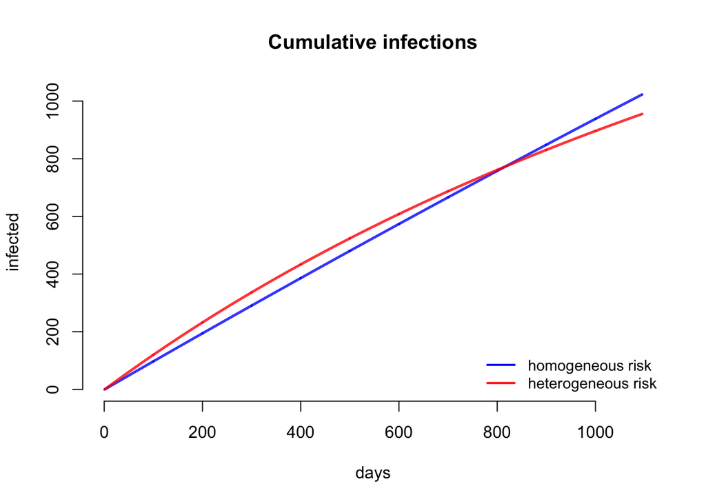

```r
plot(mod, y = c("Ip", "total.Iph.Ipm.Ipl"),
     alpha = 0.8,
     main = "Cumulative infections",
     legend = FALSE,
     ylab = "infected",
     xlab = "days",
     col = c("blue", "red"))
legend("bottomright", legend = c("homogeneous risk", "heterogeneous risk"), col = c("blue", "red"), lwd = 2, cex = 0.9, bty = "n")
```

Let’s just plot hazard / instantaneous incidence in these two populations.

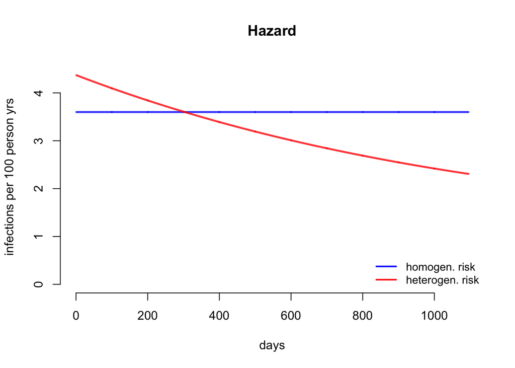

```r
#mod <- mod.manipulate(mod)

plot(mod, y=c("rate.Placebo", "rate.Placebo.het"),
     alpha = 0.8,
     ylim = c(0, 4.5),
     main = "Hazard",
     xlab = "days",
     ylab = "infections per 100 person yrs",
     legend = FALSE,
     col = c("blue", "red"))
legend("bottomright", legend = c("homogen. risk", "heterogen. risk"), col = c("blue", "red"), lwd = 2, cex = 0.9, bty = "n")
```

```r
par(mfrow=c(1,1))
```

Now we roll out a vaccine, first in the population with homogeneous exposure.

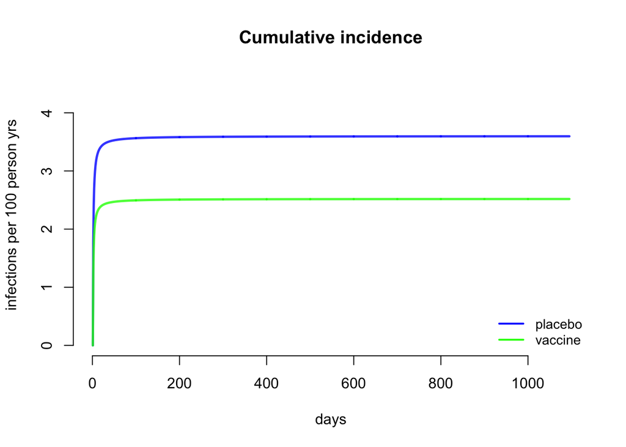

```r
mod <- mod.manipulate(mod)

plot(mod, y=c("cumul.rate.Placebo", "cumul.rate.Vaccine"),
     alpha = 0.8,
     ylim = c(0, 4.5),
     main = "Cumulative incidence",
     xlab = "days",
     ylab = "infections per 100 person yrs",
     legend = FALSE,
     col = c("blue", "green"))
legend("bottomright", legend = c("placebo", "vaccine"), col = c("blue", "green"), lwd = 2, cex = 0.9, bty = "n")
```

Vaccine now in the heterogeneous risk population, added to the above plot

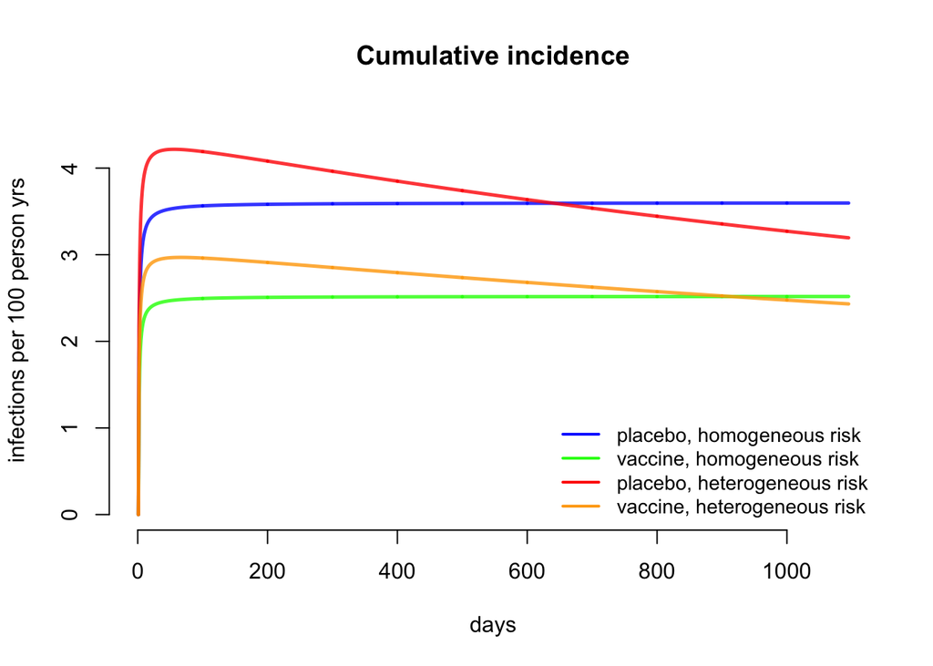

```r
mod <- mod.manipulate(mod)

plot(mod, y=c("cumul.rate.Placebo", "cumul.rate.Vaccine", "cumul.rate.Placebo.het", "cumul.rate.Vaccine.het"),
     alpha = 0.8,
     ylim = c(0, 4.5),
     main = "Cumulative incidence",
     xlab = "days",
     ylab = "infections per 100 person yrs",
     legend = FALSE,
     col = c("blue", "green", "red", "orange"))
legend("bottomright", legend = c("placebo, homogeneous risk", "vaccine, homogeneous risk", "placebo, heterogeneous risk", "vaccine, heterogeneous risk"), col = c("blue", "green", "red", "orange"), lwd = 2, cex = 0.9, bty = "n")
```

Instantaneous incidence / hazard, for the same comparison

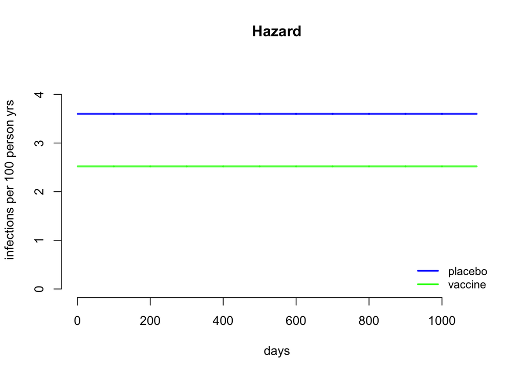

```r
mod <- mod.manipulate(mod)

plot(mod, y=c("rate.Placebo", "rate.Vaccine"),
     alpha = 0.8,
     ylim = c(0, 4.5),
     main = "Hazard",
     xlab = "days",
     ylab = "infections per 100 person yrs",
     legend = FALSE,
     col = c("blue", "green"))
legend("bottomright", legend = c("placebo", "vaccine"), col = c("blue", "green"), lwd = 2, cex = 0.9, bty = "n")
```

Vaccine now in the heterogeneous risk

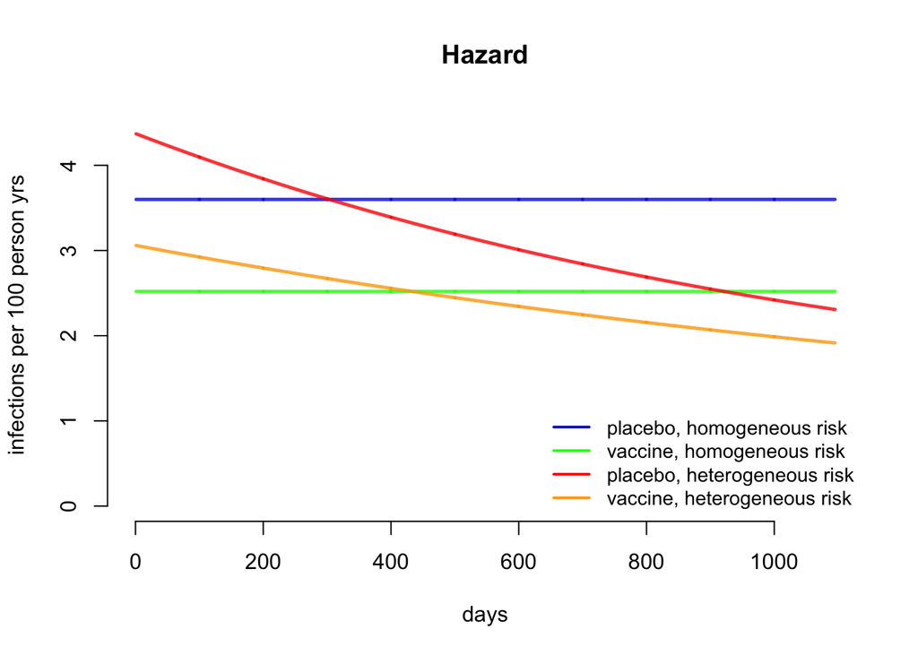

```r
mod <- mod.manipulate(mod)

plot(mod, y=c("rate.Placebo", "rate.Vaccine", "rate.Placebo.het", "rate.Vaccine.het"),
     alpha = 0.8,
     ylim = c(0, 4.5),
     main = "Hazard",
     xlab = "days",
     ylab = "infections per 100 person yrs",
     legend = FALSE,
     col = c("blue", "green", "red", "orange"))
legend("bottomright", legend = c("placebo, homogeneous risk", "vaccine, homogeneous risk", "placebo, heterogeneous risk", "vaccine, heterogeneous risk"), col = c("blue", "green", "red", "orange"), lwd = 2, cex = 0.9, bty = "n")
```

Now we can move to vaccine efficacy estimates. We use hazard (instantaneous incidence) rather than cumulative incidence.

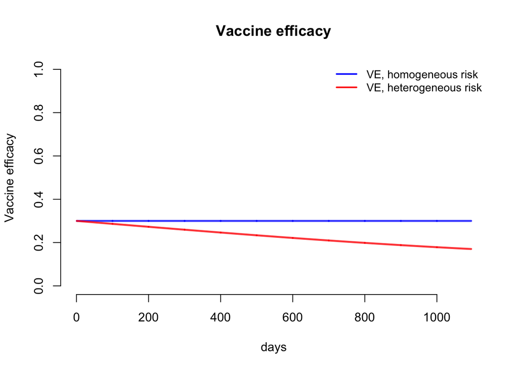

```r
plot(mod, y=c("VE1.inst", "VE2.inst"),
     alpha = 0.8,
     main = "Vaccine efficacy",
     legend = FALSE,
     xlab = "days",
     ylab = "Vaccine efficacy",
     col = c("blue", "red"))
legend("topright", legend = c("VE, homogeneous risk", "VE, heterogeneous risk"), col = c("blue", "red"), lwd = 2, cex = 0.9, bty = "n")
```

This simple example shows that exposure heterogeneity in a simplified HIV vaccine trial can result in waning *realized* vaccine efficacy, even as the per-contact vaccine efficacy (`epsilon`) remains the same. Also note that exposure heterogeneity in a longitudinal trial or study population may result in elevated incidence in the early stages of the study, as the high risk subgroup is depleted more quickly than the medium and low risk subgroups.

*Maybe add: time-to-event data from my model via survival curves*

### Model calibration with ABC

#### Our question is: What parameter value combinations of `risk`, `high risk subgroup frequency`, and `epsilon` are consistent with some observed value of VE?

Now we start to calibrate with calibrating our model to some real populations, with the goal of using to assess the impact of exposure heterogeneity on VE estimates. Our goal is to calibrate our SI vaccine trial model to the: RV144 Thai vaccine trial; HVTN 702 South Africa vaccine trial; AMP trials of the VRC01 bnAb, and then use these calibrations to explore the parameter space that can lead to waning efficacy (within a trial) or different VE (between two trials).

In a regular epidemic modeling scenario (e.g. not a vaccine trial) we would be calibrating the parameters for which we don’t have exact/good empirical estimates; for this SI model that would include the risk multiplier and the subgroup frequencies of each risk group. But with this experiment one of our main goals is to identify a level of exposure heterogeneity in an HIV population that is consistent with some frailty VE results (e.g. either the ~0% VE in HVTN 702 or the waning PE in the AMP bnAB trials).

Now, to do that we have to set target stats for the calibration. I first thought that we needed to set target stats for the placebo and vaccine arms separately. i.e. We first calibrate the model to the placebo arms, using incidence as the single target stat, and we vary only the `lambda` parameter. We get a value for `lambda` from the placebo calibrations that we then *set* for the vaccine calibrations, and in the vaccine calibrations we calibrate to the `risk multiplier` and the `initial conditions` (i.e., the %s of the population that are high and low risk, specifically.)

But, now I am thinking that we just do a first calibration of `lambda` and `risk` to the placebo arm, then next we can calibrate `epsilon` to the incidence in the vaccine arm.

### Calibrate `lambda` to RV144 placebo incidence

### Target stats

So first let’s calibrate `lambda` and `risk` to RV144 placebo incidence. RV144 placebo incidence declined over the course of the trial (0.39, 0.32, 0.28); there were 74 cumulative infections in the placebo arm.

Set the target stats:

```r
time <- c(360,720,1080)  # 3 years
placebo.incidence <- c(0.39, 0.32, 0.28)    # incidence per 100 person years; adjust accordingly
vaccine.incidence <- c(0.15, 0.21, 0.20)
VE.target <- c(0.6, 0.4, 0.3)
target.stats <- data.frame(time, placebo.incidence, vaccine.incidence, VE.target)
```

These data are pulled from RV144 output. We also have (probably poor) estimates of the size of the high, medium, and low risk subgroups from RV144:

From Rerks-Ngarm, 2009:

“We assessed subjects’ risk of HIV infection using a self-administered behavioral questionnaire at baseline and every 6 months thereafter. First, volunteers categorized themselves as being at high, moderate, or low risk for HIV infection. A second approach categorized subjects as being at high risk if they reported being at high risk or reported any high-risk behavior (e.g., needle sharing, multiple sex partners, commercial sex work, and symptoms of sexually transmitted disease). Volunteers were considered to be at low risk if they perceived their risk as low; if they reported that in the previous 6 months they had had no more than one sex partner and no sexual contact with a commercial sex worker, a partner of the same sex, an HIV-infected partner, a partner who used injection drugs, or a partner who had multiple partners; and if they reported having had no symptoms of a sexually transmitted disease or incarceration within 6 months before study entry. Moderate-risk subjects were considered to be at neither low nor high risk.”

### Calibration input model

Set up the function to wrap the EpiModel functions and make the incidence output file. In this function you can see that we are calibrating to the placebo incidence in a population with heterogeneous exposure.

```r
f <- function(x) {
  param <- param.dcm(beta = 0.004,
                     c = 90/365,
                     prev = 0.10,
                     #lambda = beta*c*prev,
                     #lambda = 0.000096,
                     lambda = x[1],
                     epsilon = 0.3,
                     #risk = 3)
                     risk = x[2])
  init <- init.dcm(Sp = 5000, Ip = 0,
                 Sv = 5000, Iv = 0,
                 Sph = 2500, Iph = 0,    #placebo, high risk
                 Spm = 5000, Ipm = 0,   #placebo, medium risk
                 Spl = 2500, Ipl = 0,    #placebo, low risk
                 Svh = 2500, Ivh = 0,    #vaccine
                 Svm = 5000, Ivm = 0,    #vaccine
                 Svl = 2500, Ivl = 0,    #vaccine
                 SIp.flow = 0, SIv.flow = 0,
                 SIph.flow = 0, SIpm.flow = 0, SIpl.flow = 0,
                 SIvh.flow = 0, SIvm.flow = 0, SIvl.flow = 0)
  control <- control.dcm(nsteps = 365*3, new.mod = si_ode)

  mod <- dcm(param, init, control)
  mod <- mod.manipulate(mod)
  mod <- as.data.frame(mod)

  matchedTimes <- mod$time %in% target.stats$time
  #out <- mod$VE.inst[matchedTimes]
  out <- mod$rate.Placebo.het[matchedTimes]

  return(out)
}
```

### Specify priors for parameters (or initial conditions)

The `beta` and `c` parameters are the transmission rate per contact and the contact rate, respectively. For now we keep these together in the `lambda` parameter, due to non-identifiability. Below we just set priors for `lambda` and `risk` (the risk multiplier that defines the elevated transmission risk for the high risk subgroup. We also will want to set priors for some of the initial conditions eventually.

```r
priors  <- list(#c("unif", 0.003, 0.008),      # beta
                #c("unif", 60/365, 120/365))    # c
                c("unif", 0.0000005, 0.000005),  # lambda
                #c("unif", 0.01, 0.5))         # epsilon
                c("unif", 3, 15))            # risk multiplier
```

For this I just use ABC_rejection from the `easyABC` R package, which just draws the parameters to vary from the prior distributions, uses these values in a simulation, and repeats `nb_simul` times. After `nb_simul` simulations, the simulations closest with summary stats closest to the target stats are kept; these give an approximate posterior distribution of the model parameters.

```r
fit.rej <- ABC_rejection(model = f,
                     prior = priors,
                     nb_simul = 2000,
                     summary_stat_target = target.stats$placebo.incidence,
                     tol = 0.25,
                     progress_bar = TRUE)
```

```r
fit <- fit.rej
par(mfrow = c(1, 2))
plot(density(fit$param[, 1], from = 0.0000001,  to = 0.000005),
     main = "lambda",
     xlab = "lambda",
     xlim = c(0.0000001, 0.000005),
     #ylim = c(0, 10),
     col=2)
#lines(density(fit$param[, 1], from = 0.01,  to = 0.5), col = 2)
#abline(v = VE.target[1], lty = 2, col = 1)
#legend("topright", legend = c("Truth", "Posterior"),
#      lty = c(1, 2), col = 1:2, lwd = 2)

plot(density(fit$param[, 2], from = 1, to = 15),
     main = "risk",
     xlab = "risk multiplier",
     xlim = c(1, 15))
     #ylim = c(0, 0.5))
#lines(density(fit3$param[, 2], from = 1, to = 20), col = 2)
#abline(v = 1.5, lty = 2)
#legend("topright", legend = c("Posterior"),
#      lty = 1, col = 1, lwd = 2)
```

[output not shown]